# Projectile-based weapons

We’re at a point now ready to focus our attention on the weapons system. It’s is one of the more complicated features of this series.

We’ll create two types of weapons:

1. A cannon that launches projectiles. The weapon targets a room and automatically fires at it.
2. A sweeping laser beam. The user draws a line that can cross rooms and inflict damage to everything it crosses.

First, we’ll look at AI-controlled weapons because they don’t have the added complexity of player interaction.

In this lesson, we’ll do the groundwork for the weapons system by creating:

1. The base scene for the projectile-based weapon.
2. The projectile scene.

## The base weapon scene

The base scene for our weapons is the projectile-based weapon.

The laser weapon will build on top of the projectile scene. As we’ll see, it has quite a few elements in common. For the time being, we start with the base setup.

Open a new scene file and choose the

[figure not shown]

`Sprite` node as the root of the tree.

Rename the root node to *Weapon*. We use the same root name for both projectile and laser weapons to reference it in code in the same manner, no matter its type.

Add a

[figure not shown]

`Tween` node as a child.

[figure not shown]

The essential property of a weapon is its cooldown time, so the ships can’t fire consecutively without any limit. We’ll use the

[figure not shown]

`Tween` node to implement this functionality.

It will be clear why we use

[figure not shown]

`Tween` instead of the

[figure not shown]

`Timer` node later when we get to the player weapons. For now, it’s enough to know that it acts as a charging timer.

To set up the

[figure not shown]

`Sprite`, follow the instructions from the following image:

- Use the `Assets.svg` for the *Texture*.
- And set the region to the square cannon: `Rect2(64, 416, 32, 32)`.

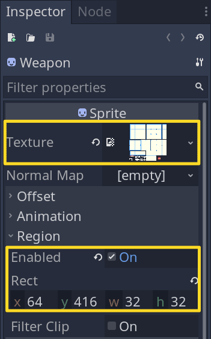

Your scene should be this simple-looking shape:

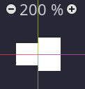

Save your scene at `res://TacticalSpaceCombat/Ship/Weapons/WeaponProjectile.tscn`.

## The projectile

Since our first weapon is the projectile weapon, we need a projectile for it to fire.

Create a new scene and pick a

[figure not shown]

`RigidBody2D` as the root node. Our projectiles will have to detect room and shield collisions. We also want it to move across the screen.

Instead of coding the motion ourselves, we’ll use the functionality provided by the

[figure not shown]

`RigidBody2D` node.

Rename the base node to *Projectile* and add a

[figure not shown]

`Sprite` and a

[figure not shown]

`CollisionShape2D` as children.

[figure not shown]

Let’s first set the *Projectile* properties:

We set *Projectile*’s default orientation towards the right. We set *Velocity* to `Vector2(750, 0)` under *Linear*. This gives a constant velocity to the

[figure not shown]

`RigidBody2D` node, and Godot will take care of its motion.

We uncheck the boxes under *Layer* and *Mask* because we’ll be setting these from code later, depending on whether the player or the AI shots the *Projectile*.

We don’t want the *Projectile* to interact with the player rooms and shield if the player is shooting. And vice-versa with the AI.

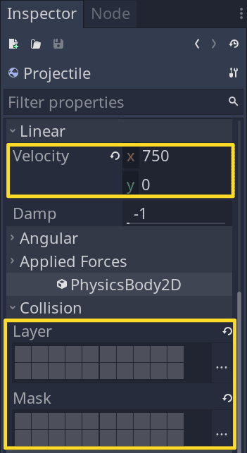

Set up the

[figure not shown]

`Sprite` to use `Assets.svg` as usual, and, once again:

- We turn on *Region -> Enabled*.
- We set the *Region -> Rect* to `Rect2(130, 419, 28, 12)`. This corresponds to a missile sprite.

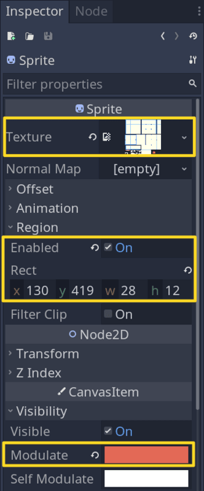

I set *Visibility -> Modulate* to a warm orange, `#e36956`.

For

[figure not shown]

`CollisionShape2D`, assign a

[figure not shown]

`CapsuleShape2D` to *Shape* with:

- A *Radius* of `4`.
- A *Height* of `18`.

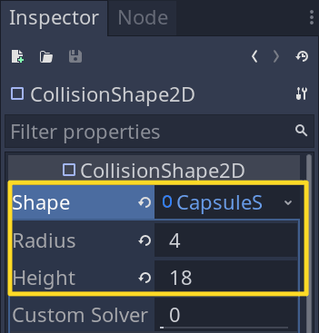

Rotate the

[figure not shown]

`CollisionShape2D` by `90` degrees, either left or right, to align with the missile.

Save the scene at `res://TacticalSpaceCombat/Ship/Weapons/Projectile.tscn`.

## The code

The two types of weapons have a lot of functionality in common. Given this, we use class inheritance so we don’t duplicate code unnecessarily.

The *Projectile* is a self-contained scene that traverses from one viewport to the other to reach the opponent ship.

We start by looking at the *Projectile* first.

### Coding the projectile

We work with a

[figure not shown]

`RigidBody2D` so Godot handles its motion with the `linear_velocity` property.

We use a set distance the *Projectile* has to travel before removing it from the scene tree. We’ll see later how to transfer a *Projectile* from one viewport to another.

For now, we’ll focus on deleting it from the tree after it has traveled some distance.

Assign a script to the root *Projectile* node with the following content:

```
class_name Projectile
extends RigidBody2D

const MAX_DISTANCE := 2000


func _process(_delta: float) -> void:
    if position.length() > MAX_DISTANCE:
        queue_free()
```

The *Projectile* starts moving as soon as we attach it to the scene tree. If it travels more than `MAX_DISTANCE`, we delete the node from the tree.

And thanks to using

[figure not shown]

`RigidBody2D`, that’s all there is to coding the *Projectile*.

### Coding the weapon

The two types of weapons we’ll create share some functionality:

- They first charge over a certain period of time.
- Once fully charged, they fire.

We start with a base class to avoid duplicate code.

```
class_name Weapon
extends Sprite

## These two properties define the range of the `_charge` variable below.
##
## We also use them later, with the player UI progress bar to display the
## charge amount.
const MIN_CHARGE := 0
const MAX_CHARGE := 100

## Controls the time it takes for the weapon to charge completely and get ready to fire.
export var charge_time := 2.0

## We'll use this property to get the weapon to fire.
var is_charging := false setget set_is_charging

## This variable keeps track of the current charge level.
## We'll later tie it with the player weapon's interface.
var _charge := MIN_CHARGE

onready var tween: Tween = $Tween
```

Since we inherit from this script to specialize for the two weapon types, I gave it the class name `Weapon`.

Let’s move on to the `_ready()` function:

```
func _ready() -> void:
    # We'll use the `Tween` to charge the weapon below. When the animation
    # finishes, the charge is full, so we use this signal to set `is_charging`
    # to `false`.
    tween.connect("tween_all_completed", self, "set_is_charging", [false])

    # We trigger a call to the setter function using `self`.
    self.is_charging = true
```

Now, for the missing setter function:

```
## Virtual function to overwrite to define how each weapon fires.
func fire() -> void:
    pass


func set_is_charging(value: bool) -> void:
    is_charging = value
    # When we start charging, we animate the `_charge` property using our `Tween` node.
    if is_charging:
        tween.interpolate_property(self, "_charge", MIN_CHARGE, MAX_CHARGE, charge_time)
        tween.start()

    # Every time we update the `is_charging` value, attempt to fire.
    # We'll handle the condition to fire in each weapon, inside the `fire()` function.
    # This lowers the cognitive burden of checking for fire conditions every time we
    # call the function.
    fire()
```

With this, we have finished implementing the base class for our weapons.

Next, we’ll code the cannon, which fires the projectiles.

### The projectile weapon code

Return to the *WeaponProjectile* scene. We need to assign a script to its root node that extends the `Weapon` class we wrote above.

For the time being, we keep the script to its bare minimum, for testing purposes, before getting into the nitty-gritty of the AI logic.

```
extends Weapon

## The projectile to spawn and fire.
const Projectile := preload("Projectile.tscn")


func fire() -> void:
    if not can_fire():
        return

    # We set `is_charging` to `true` to start the `Tween` animation.
    self.is_charging = true

    var projectile: RigidBody2D = Projectile.instance()
    # We adjust `linear_velocity` by `rotation` because we can orient the weapon
    # in any direction we want.
    projectile.linear_velocity = projectile.linear_velocity.rotated(rotation)
    add_child(projectile)


func can_fire() -> bool:
    return not is_charging
```

Now, our weapon is ready to attach to the ship.

## Updating the ship for weapons

Open the *ShipTemplate* scene file and add a new

[figure not shown]

`Node2D` node to the scene. Rename it *Weapons*:

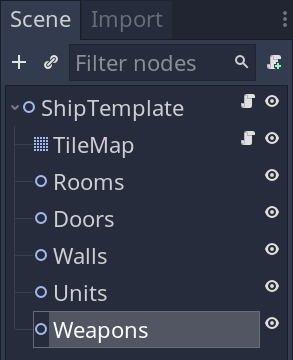

We’ll be grouping the weapons system under the *Weapons* node. If you want to do a quick test, you can go to the *ShipAI* scene and add one of our fancy new *WeaponProjectile* scenes under *Weapons*:

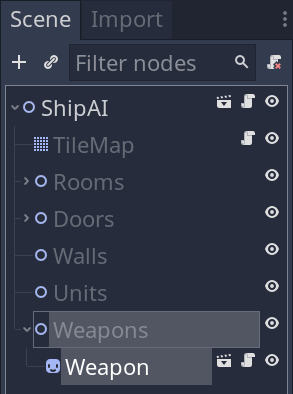

I’ve placed *Weapon* relative to the lefmost room like this:

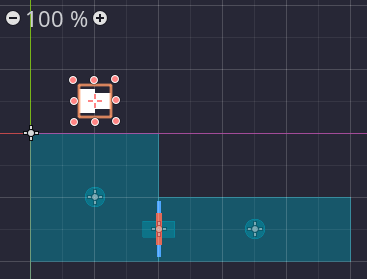

*Note* that I rotated it `180` degrees to face the player ship. The larger rectangle represents where the projectile will come out.

This will also test if the *Projectile* moves in the right direction, as we had to consider the *Weapon*’s rotation.

At this point you should have a continuously firing projectile-based weapon.

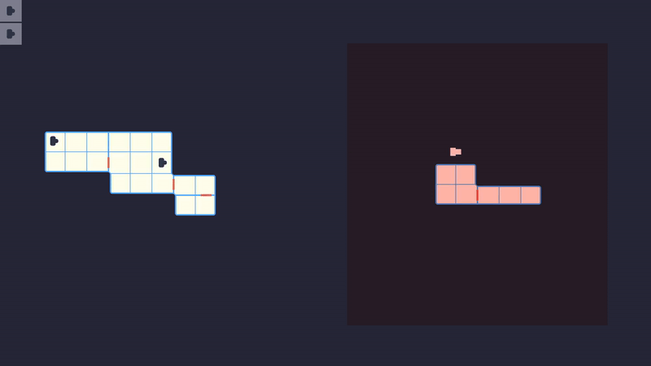

*Note* that I tinted the viewport so we can see its limits in the video.

## Conclusion

In this lesson, we started our journey into implementing the weapons system.

We saw how to:

- Use the

[figure not shown]

  `RigidBody2D` node to let Godot take care of the mundane motion calculations for us.
- Use inheritance with custom classes so we won’t duplicate functionality in code.
- Add a node to the scene tree from the code.
- Remove a node from code, simply based on a condition.

In the next lesson, we’ll work on an AI controller for the projectile weapon. We’ll cover essential concepts that will help us understand how the more complex laser weapon functions.

## Code reference

`res://TacticalSpaceCombat/Ship/Weapons/Projectile.gd`:

```
class_name Projectile
extends RigidBody2D

const MAX_DISTANCE := 2000


func _process(_delta: float) -> void:
    if position.length() > MAX_DISTANCE:
        queue_free()
```

`res://TacticalSpaceCombat/Ship/Weapons/Weapon.gd`:

```
class_name Weapon
extends Sprite

const MIN_CHARGE := 0
const MAX_CHARGE := 100

export var charge_time := 2.0

var is_charging := false setget set_is_charging

var _charge := MIN_CHARGE

onready var tween: Tween = $Tween


func _ready() -> void:
    tween.connect("tween_all_completed", self, "set_is_charging", [false])
    self.is_charging = true


func fire() -> void:
    pass


func set_is_charging(value: bool) -> void:
    is_charging = value
    if is_charging:
        tween.interpolate_property(self, "_charge", MIN_CHARGE, MAX_CHARGE, charge_time)
        tween.start()
    fire()
```

`res://TacticalSpaceCombat/Ship/Weapons/WeaponProjectile.gd`:

```
extends Weapon

const Projectile := preload("Projectile.tscn")


func fire() -> void:
    if not can_fire():
        return

    self.is_charging = true
    var projectile: RigidBody2D = Projectile.instance()
    projectile.linear_velocity = projectile.linear_velocity.rotated(rotation)
    add_child(projectile)


func can_fire() -> bool:
    return not is_charging
```